# The Double Slit Experiment: Interference Pattern

## © McEwen, 2025

### Permission has not been granted to share, distribute, or copy.

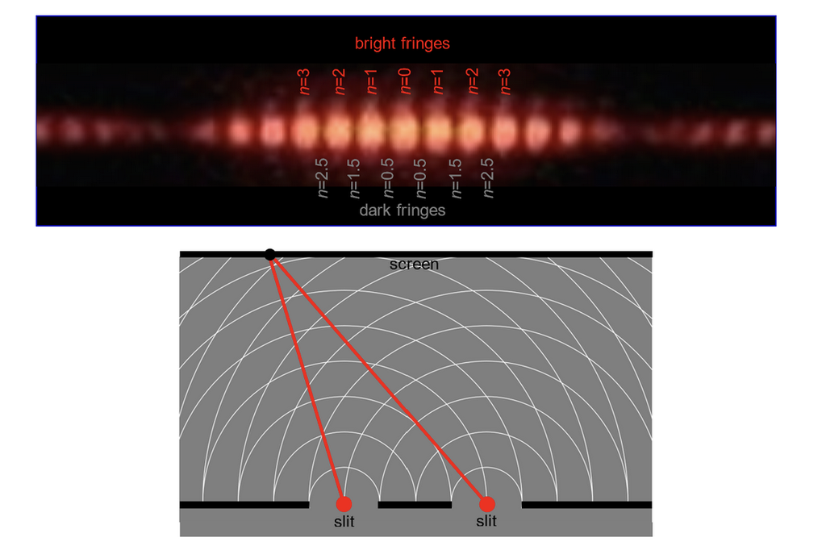

# The Double Slit Experiment: Interference Pattern

Upon passing through the slits, the light waves diffract and interfere, producing a pattern of bright and dark fringes on the screen — an interference pattern resulting from the superposition of the two diffracted wavefronts.

We begin by analyzing the interference pattern in the double-slit experiment. Later, we will study the diffraction pattern.

**Question 1:** What is the difference between interference and diffraction?

**Answer**

**Interference** occurs when two or more waves overlap in space or time, combining through superposition. Depending on their relative phase, the waves can reinforce each other (constructive interference) or cancel each other (destructive interference).

**Diffraction** is the bending and spreading of waves when they pass around obstacles or through openings. It occurs for all types of waves and becomes more pronounced when the obstacle or aperture is comparable in size to the wavelength.

[video not shown]

We now aim to determine the interference pattern of the double-slit experiment.  
Consider two waves emerging from the two slits and meeting at a common observation point on the screen. The observaton point is labeled $y$.

The wave from the lower slit travels an additional distance $\Delta r$ compared to the wave from the upper slit.  
From the geometry of the setup, the path difference is given by

\begin{equation} \Delta r = d \sin \theta \end{equation}

where $d$ is the slit separation and $\theta$ is the angle measured from the central axis (the normal to the slits).

If the path difference $\Delta r$ is an integer multiple of the wavelength, the waves will arrive **in phase** and produce **constructive interference**, resulting in bright fringes on the screen. This condition is

\begin{equation} d \sin \theta = m \lambda, \quad m = 0, \pm 1, \pm 2, \ldots \end{equation}

If the path difference $\Delta r$ is an odd multiple of half a wavelength, the waves will arrive **out of phase** and produce **destrucitve interference**, resulting in dark regions on the screen. This condition is

\begin{equation} d \sin \theta = \left(m + \tfrac{1}{2}\right)\lambda, \quad m = 0, \pm 1, \pm 2, \ldots \end{equation}

The locations of maximal intensity, i.e., constructive interference, are called **fringes** (the bright spots).  
The fringes are indexed by $m$, with $m = 0$ corresponding to the central bright fringe, $m = \pm 1$ for the fringes adjacent to the center, and so on.

**Question 2**  
For green light of wavelength $\lambda = 550\ \text{nm}$, what is the smallest nonzero path difference $\Delta r$ that produces constructive interference in a double-slit experiment?

**Answer**

Constructive interference occurs when

\begin{equation} \Delta r = m \lambda, \quad m = 0, \pm 1, \pm 2, \ldots \end{equation}

The smallest nonzero path difference corresponds to $m = 1$:

\begin{equation} \Delta r = \lambda = 550\ \text{nm} \end{equation}

Thus, the smallest $\Delta r$ that gives a bright fringe is $550\ \text{nm}$.

**Position of Fringes**

Let $y_m$ be the position of the $m$-th bright fringe on the observation screen.  
From the geometry of the experiment, we have

\begin{equation} \tan \theta_m = \frac{y_m}{L}, \end{equation}

where $\theta_m$ is the angle associated with the $m$-th fringe and $L$ is the distance from the slits to the screen.

For small angles, $\theta_m$ is small, so we can use the approximation $\sin \theta_m \approx \tan \theta_m$.  
Substituting into the constructive interference condition $d \sin \theta_m = m \lambda$, we get

\begin{equation} \frac{m \lambda}{d} = \frac{y_m}{L}. \end{equation}

Solving for $y_m$, the position of the $m$-th fringe is

\begin{equation} y_m = \frac{m \lambda L}{d}. \end{equation}

The distance between adjacent bright fringes, $\Delta y$, is

\begin{equation} \Delta y = y_{m+1} - y_m = \frac{\lambda L}{d}. \end{equation}

**Question 3**  
For green light of wavelength $\lambda = 550\ \text{nm}$, a slit separation of $d = 0.25\ \text{mm}$, and a screen distance $L = 2\ \text{m}$, calculate the fringe spacing $\Delta y$ on the screen.

**Answer**

The fringe spacing is

\begin{equation} \Delta y = \frac{\lambda L}{d} = \frac{550 \times 10^{-9} \times 2}{0.25 \times 10^{-3}} \approx 4.4\ \text{mm}. \end{equation}

Thus, adjacent bright fringes are approximately $4.4\ \text{mm}$ apart.

**Question 4**  
If the wavelength of light is doubled while keeping $d$ and $L$ the same, how does the fringe spacing $\Delta y$ change?

**Answer**

The fringe spacing is directly proportional to the wavelength:

\begin{equation} \Delta y = \frac{\lambda L}{d}. \end{equation}

Doubling $\lambda$ doubles $\Delta y$. So the fringes will be twice as far apart.

The double-slit intensity pattern results from the combination of both **interference** and **diffraction**. So far, we have only studied the interference pattern.

The diffraction pattern depends on the slit width $a$. For smaller $a$ at fixed wavelength, the diffraction pattern spreads out more. This diffraction pattern forms an **envelope** that modulates the overall intensity of the interference fringes.

You can explore this effect using the interactive app [here](https://joemcewen-double-slit-app-double-slit-app-zmxly7.streamlit.app/).

In the app, three curves are displayed. The solid red line shows the combined double slit intensity pattern. The dashed yellow line shows the single-slit diffraction envelope. The solid orange line shows the double-slit interference pattern. The combined pattern (red) is formed by modulating the interference fringes (orange) with the diffraction envelope (yellow).

## Mathematical Description

The complete intensity pattern is given by \begin{equation} I(\theta) = I_0 \left[\frac{\sin(\beta)}{\beta}\right]^2 \left[\frac{\sin(N\alpha)}{\sin(\alpha)}\right]^2 \end{equation} where $\beta = \frac{\pi a}{\lambda} \sin\theta$ is the single-slit diffraction parameter, $\alpha = \frac{\pi d}{\lambda} \sin\theta$ is the double-slit interference parameter, and $N = 2$ for two slits.

For two slits, this simplifies to \begin{equation} I(\theta) = I_0 \left[\frac{\sin(\beta)}{\beta}\right]^2 \cos^2(\alpha). \end{equation}

The first factor represents the single-slit diffraction envelope (yellow dashed curve). The second factor produces the double-slit interference fringes (orange curve).

## Conditions for Maxima and Minima

Single-slit diffraction produces minima when \begin{equation} a \sin \theta = m \lambda, \quad m = \pm 1, \pm 2, \ldots \end{equation} where $a$ is the slit width.

Double-slit interference produces maxima when \begin{equation} d \sin \theta = m \lambda, \quad m = 0, \pm 1, \pm 2, \ldots \end{equation} where $d$ is the center-to-center separation between slits.

The combined intensity is the product of the diffraction envelope and the interference pattern.

Use the linked [app](https://joemcewen-double-slit-app-double-slit-app-zmxly7.streamlit.app/). to answer the following questions.

**Question 5**  
If the wavelength $\lambda$ is increased while all other parameters are held fixed, what happens to the diffraction envelope? What happens to the interference pattern?

**Answer**

Both the diffraction envelope and the interference pattern spread out.

For the **diffraction envelope**, the first minimum occurs at \begin{equation} a \sin \theta = \lambda. \end{equation} Increasing $\lambda$ increases the angle $\theta$ where the first minimum appears, causing the envelope to spread wider.

For the **interference fringes**, the spacing between maxima is \begin{equation} \Delta y = \frac{\lambda L}{d}. \end{equation} Increasing $\lambda$ increases $\Delta y$, so the fringes become more widely spaced.

Both effects scale linearly with wavelength.

**Question 6**  
If slit spacing $d$ is increased while all other parameters are held fixed, what happens to the diffraction envelope? What happens to the interference pattern?

**Answer**

The **diffraction envelope remains unchanged** because it depends only on the slit width $a$ and wavelength $\lambda$. The single-slit diffraction formula \begin{equation} a \sin \theta = m \lambda \end{equation} does not involve $d$.

The **interference fringes become more closely spaced**. The fringe spacing is \begin{equation} \Delta y = \frac{\lambda L}{d}. \end{equation} Increasing $d$ decreases $\Delta y$, compressing the interference pattern. More fringes appear within the same diffraction envelope.

**Question 7**  
If slit width $a$ is increased while all other parameters are held fixed, what happens to the diffraction envelope? What happens to the interference pattern?

**Answer**

The **diffraction envelope becomes narrower**. The first minimum occurs at \begin{equation} a \sin \theta = \lambda. \end{equation} Increasing $a$ decreases the angle $\theta$, compressing the diffraction envelope toward the center.

The **interference pattern remains unchanged** because it depends only on slit spacing $d$ and wavelength $\lambda$. The fringe spacing \begin{equation} \Delta y = \frac{\lambda L}{d} \end{equation} does not involve $a$.

However, fewer interference fringes fit within the narrower diffraction envelope, and the overall pattern appears dimmer at large angles.

**Question 8 (Challenge)**  
Under what condition does a bright interference fringe coincide with a diffraction minimum? Express your answer as a relationship between $a$, $d$, and the order numbers.

**Answer**

A bright interference fringe disappears when it coincides with a diffraction minimum. These are called **missing orders**.

An interference maximum occurs when \begin{equation} d \sin \theta = m_2 \lambda \end{equation} where $m_2 = 0, \pm 1, \pm 2, \ldots$

A diffraction minimum occurs when \begin{equation} a \sin \theta = m_1 \lambda \end{equation} where $m_1 = \pm 1, \pm 2, \ldots$

For these to coincide at the same angle, we divide the two equations: \begin{equation} \frac{d}{a} = \frac{m_2}{m_1}. \end{equation}

Rearranging gives the condition for missing orders: \begin{equation} m_2 = \frac{d}{a} m_1. \end{equation}

For example, if $d = 3a$, then the interference maxima at $m_2 = 3, 6, 9, \ldots$ will be suppressed because they align with diffraction minima at $m_1 = 1, 2, 3, \ldots$

```
Video saved to: /Users/joe/Desktop/p223/DoubleSlit/media/videos/480p15/DoubleSlit.mp4
```

[video not shown]

# Double Slit Interference Challenge Problems

**Problem 1: The Moving Screen**

In a double slit experiment with slit separation $d = 0.5\ \text{mm}$ and wavelength $\lambda = 600\ \text{nm}$, the screen is initially $L_1 = 2.0\ \text{m}$ from the slits. You then move the screen to $L_2 = 3.0\ \text{m}$ away.

(a) How does the fringe spacing change? Calculate both the initial and final fringe spacings.

(b) Does the intensity of the bright fringes change? Explain quantitatively.

(c) A student claims moving the screen farther makes the pattern "more spread out but dimmer." Evaluate this claim with calculations.

**Answer**

**(a) Fringe spacing change:**

The fringe spacing is given by \begin{equation} \Delta y = \frac{\lambda L}{d}. \end{equation}

Initial fringe spacing at $L_1 = 2.0\ \text{m}$: \begin{equation} \Delta y_1 = \frac{(600\times10^{-9})(2.0)}{0.5\times10^{-3}} = 2.4\ \text{mm}. \end{equation}

Final fringe spacing at $L_2 = 3.0\ \text{m}$: \begin{equation} \Delta y_2 = \frac{(600\times10^{-9})(3.0)}{0.5\times10^{-3}} = 3.6\ \text{mm}. \end{equation}

The fringe spacing increases by a factor of \begin{equation} \frac{\Delta y_2}{\Delta y_1} = \frac{L_2}{L_1} = \frac{3.0}{2.0} = 1.5. \end{equation}

**(b) Intensity change:**

The intensity decreases due to geometric spreading. The light spreads over a larger area, so intensity follows an inverse square law: \begin{equation} I \propto \frac{1}{L^2}. \end{equation}

Therefore, the intensity ratio is \begin{equation} \frac{I_2}{I_1} = \left(\frac{L_1}{L_2}\right)^2 = \left(\frac{2.0}{3.0}\right)^2 = \frac{4}{9} \approx 0.44. \end{equation}

The bright fringes are only about **44% as bright** at the farther distance.

**(c) Evaluating the student's claim:**

The student is **correct**:

- **"More spread out"**: True — fringe spacing increases by 50% (from 2.4 mm to 3.6 mm).
- **"Dimmer"**: True — intensity drops to 44% of the original value.

This is a trade-off in interference experiments: you gain resolution (larger fringe spacing makes them easier to measure) but lose brightness. The total energy passing through any cross-section is conserved, but it's distributed over a larger area.

**Problem 2: The Underwater Experiment**

A double slit experiment in air produces 10 equally-spaced bright fringes across a 5.0 cm width on the screen. The entire apparatus (slits and screen) is then carefully submerged in water with refractive index $n = 1.33$.

(a) How many bright fringes now appear across the same 5.0 cm width? Explain your reasoning.

(b) If you want to restore the original 10-fringe pattern, should you move the screen closer or farther from the slits? By what factor must you change the distance?

(c) Explain why this happens using both classical wave theory and the photon perspective.

**Answer**

**(a) Number of fringes in water:**

In air, the fringe spacing is \begin{equation} \Delta y_{\text{air}} = \frac{\lambda_{\text{air}} L}{d}. \end{equation}

If 10 fringes span 5.0 cm, then \begin{equation} 10 \cdot \Delta y_{\text{air}} = 5.0\ \text{cm}. \end{equation}

In water, the wavelength becomes \begin{equation} \lambda_{\text{water}} = \frac{\lambda_{\text{air}}}{n} = \frac{\lambda_{\text{air}}}{1.33}. \end{equation}

The new fringe spacing is \begin{equation} \Delta y_{\text{water}} = \frac{\lambda_{\text{water}} L}{d} = \frac{\lambda_{\text{air}} L}{n \cdot d} = \frac{\Delta y_{\text{air}}}{n} = \frac{\Delta y_{\text{air}}}{1.33}. \end{equation}

Number of fringes in the same 5.0 cm: \begin{equation} N_{\text{water}} = \frac{5.0\ \text{cm}}{\Delta y_{\text{water}}} = \frac{5.0\ \text{cm}}{\Delta y_{\text{air}}/1.33} = 10 \times 1.33 = 13.3 \approx 13\ \text{bright fringes}. \end{equation}

**(b) Restoring the original pattern:**

To get 10 fringes again, we need \begin{equation} \Delta y_{\text{new}} = \Delta y_{\text{air}}. \end{equation}

Since $\Delta y = \frac{\lambda L}{d}$, and $\lambda_{\text{water}} = \lambda_{\text{air}}/n$: \begin{equation} \frac{\lambda_{\text{water}} L_{\text{new}}}{d} = \frac{\lambda_{\text{air}} L_{\text{original}}}{d}. \end{equation}

Solving for $L_{\text{new}}$: \begin{equation} \frac{\lambda_{\text{air}}}{n} \cdot L_{\text{new}} = \lambda_{\text{air}} \cdot L_{\text{original}}. \end{equation}

\begin{equation} L_{\text{new}} = n \cdot L_{\text{original}} = 1.33 \times L_{\text{original}}. \end{equation}

You must move the screen **farther away** by a factor of **1.33** (33% increase in distance).

**(c) Physical explanation:**

**Classical wave perspective:** Light slows down in water (speed becomes $c/n$), which reduces its wavelength by the same factor. The frequency remains constant (determined by the source), so $\lambda = v/f$ decreases. Shorter wavelength means the path difference required for constructive interference occurs at smaller angles, compressing the fringe pattern.

**Photon perspective:** Each photon's energy $E = h f$ stays constant (frequency unchanged), but its momentum increases in the medium: $p = h/\lambda$ becomes larger as $\lambda$ decreases. The photon wavelength determines the interference pattern, and this de Broglie wavelength is shorter in water, leading to more closely spaced fringes.

Both perspectives agree: the refractive index reduces the effective wavelength, compressing the interference pattern.